# Praca domowa 5

Małgorzata Wachulec

17 listopada 2018

## Wstęp - ankieta, wykresy i pytania

Na potrzeby tej pracy przygotowałam [ankietę](https://goo.gl/forms/kFpB9ggO1FzaqQgG2), w której zawarte są 2 wykresy - Wykres 1. (ten wykres 3D został zrobiony w Excel-u) i Wykres 2. (wykres zrobiony przy użyciu biblioteki ggplot2) oraz identyczne zestawy pytań:

1. Ile wynosiła średnia krajowa w 2007 roku?
2. Ile wynosiło średnie wynagrodzenie pracowników biurowych w 2007 roku?
3. Ile wynosiła średnia krajowa w 2017 roku?
4. Ile wynosiło średnie wynagrodzenie pracowników biurowych w 2017 roku?
5. Jaki był przyrost średniej krajowej w latach 2007-2017?
6. Jaki był przyrost średniego wynagrodzenia pracowników biurowych w latach 2007-2017?
7. Jak zwiększyła się różnica między pensją krajową, a pensją pracowników biurowych w latach 2007-2017?

Uwaga!

Jedynie część danych jest prawdziwa, a brakujące dane zostały wymyślone na potrzeby projektu.

Poniższe zestawienie zostało oparte na pierwszych 15 zgłoszonych odpowiedziach.

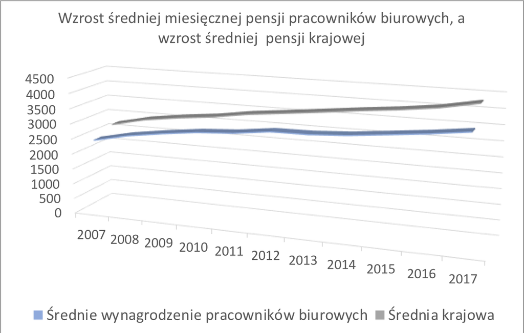

Wykres 1. zrobiony w Excel-u

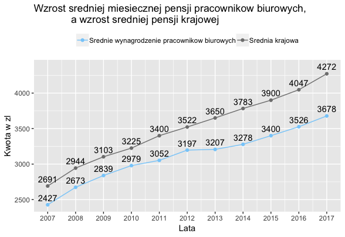

Wykres 2. zrobiony za pomocq ggplot2

## Odpowiedzi ankietowanych

1. Ile wynosiła średnia krajowa w 2007 roku?

Prawidlłowa opowiedź to ok. 2500 zł. Na podstawie Wykresu 1. jedynie dwie trzecie ankietowanych odpowiedziało dobrze, a na podstawie Wykresu 2. - ponad 90 %.

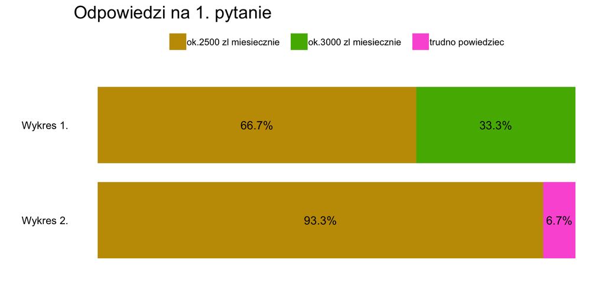

2. Ile wynosiło średnie wynagrodzenie pracowników biurowych w 2007 roku?

Prawidlłowa opowiedź to ok. 2500 zł. Na podstawie Wykresu 1. jedynie 40 % ankietowanych odpowiedziało dobrze. Więcej ankietowanych (53.3 %) wybrało odpowiedź “ok. 2000 zł”, z czego wynika, że na pierwszym wykresie trudno jest ocenić wartości przedstawionych danych.

Na podstawie Wykresu 2. aż około 93 % ankietowanych odpowiedziało dobrze, a pozostali zaznaczyli odpowiedź “Trudno powiedzieć”.

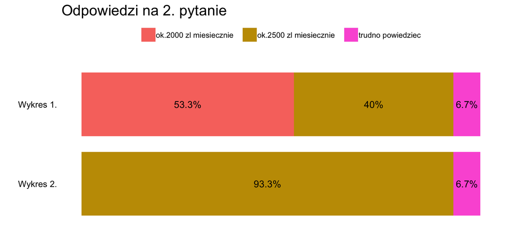

3. Ile wynosiła średnia krajowa w 2017 roku?

Prawidłowa opowiedź to 4272 zł, co w moim przekonaniu wynosi ok. 4500 zł. Wtedy na podstawie Wykresu 1. jedynie 33.3 % ankietowanych odpowiedziało dobrze, a na podstawie Wykresu 2. - tylko 26.7 %. W obu przypadkach więcej ankietowanych wybrało odpowiedź “ok. 4000 zł” zamiast poprawnej, z czego wynika, że nawet kiedy wartości były wypisane na Wykresie 2., to nadal ankietujący częściej wybierali odpowiedź “ok. 4000 zł”.

Jeżeli założymy, że obie odpowiedzi “ok. 4000 zł” i “ok. 4500 zł” są prawidłowe, to wyniki na postawie obu wykresów można uzać za równie dobre - wtedy dobrze odpowiedziało 80 % ankietowanych.

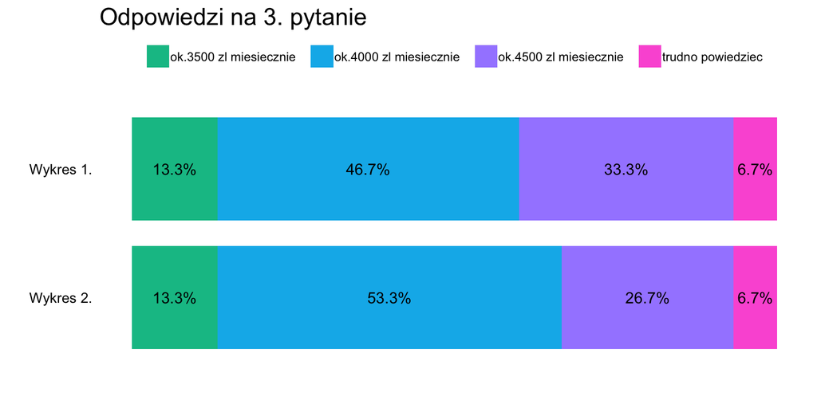

4. Ile wynosiło średnie wynagrodzenie pracowników biurowych w 2017 roku?

Prawidlłowa opowiedź to ok. 3500 zł. Na podstawie Wykresu 1. 53.3 % ankietowanych odpowiedziało dobrze, a na podstawie Wykresu 2. - 60 %. Na obu wykresach aż jedna trzecia ankietowanych wybrała odpowiedź “ok. 4000 zł” zamiast prawidłowej.

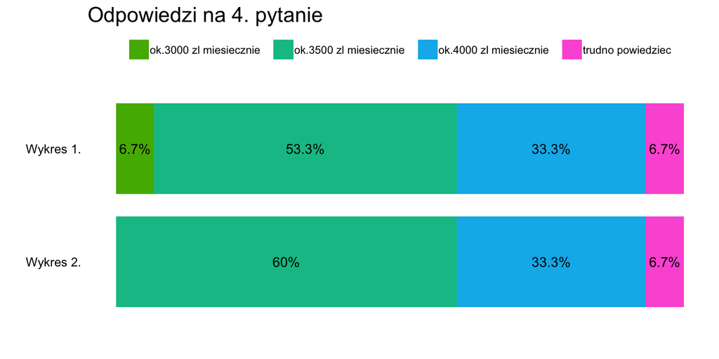

5. Jaki był przyrost średniej krajowej w latach 2007-2017?

Prawidlłowa opowiedź to 60 %. Na podstawie Wykresu 1. 26.7 % ankietowanych odpowiedziało dobrze, a na podstawie Wykresu 2. jedynie 20 %.

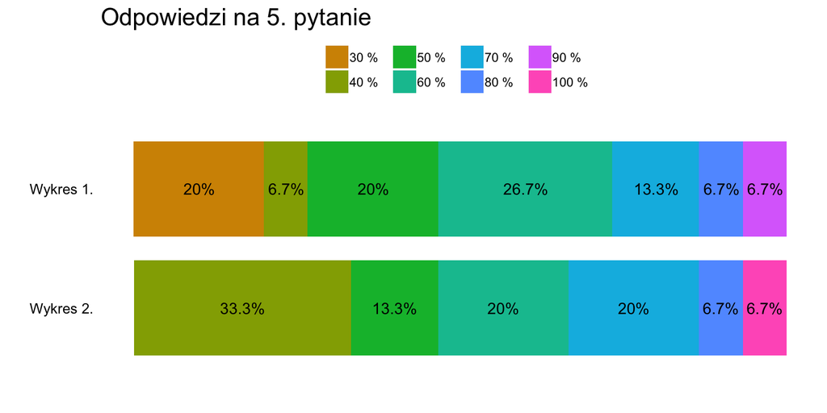

6. Jaki był przyrost średniego wynagrodzenia pracowników biurowych w latach 2007-2017?

Prawidlłowa opowiedź to 50 %. Na podstawie Wykresu 1. 20 % ankietowanych odpowiedziało dobrze, a na podstawie Wykresu 2. - 26.7 %.

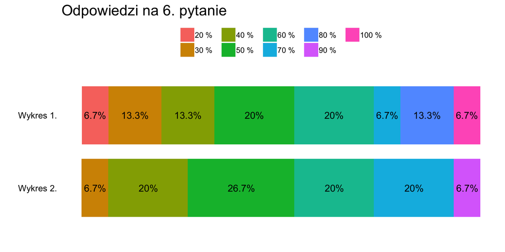

7. Jak zwiększyła się różnica między pensją krajową, a pensją pracowników biurowych w latach 2007-2017?

Różnica między pensjami w 2017 roku jest ok. 2 razy większa niż w 2007 roku. Na podstawie Wykresu 1. tylko 6.7 % ankietowanych podało tę odpowiedź. Na podstawie Wykresu 2. aż 53.3 % ankietowanych odpowiedziało dobrze.

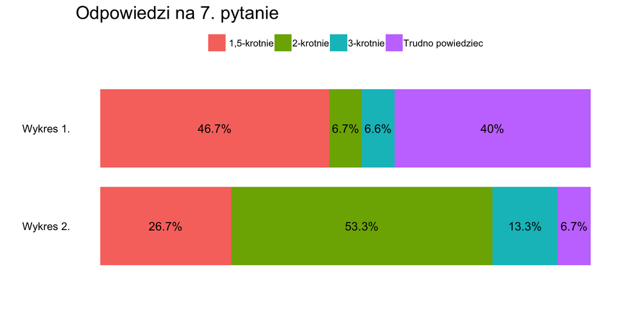

## Podsumowanie

W pytaniach 1-4, które mają na celu sprawdzić, czy ankietowany jest w stanie odczytać dane z wykresu, zazwyczaj odpowiedzi udzielone na podstawie Wykresu 2. były bardziej trafne, niż te udzielone na podstawie Wykresu 1. Wyjątkiem tu było pytanie 3., w którym ankietowani zaorkąglali 4272 do 4000 zamiast do 4500. Może to wynikać między innymi z tego, że na osi y Wykresu 2. brakuje zaznaczenia, gdzie znajduje się wartość 4500. Być może gdyby jej nie zabrakło ankietowani udzieliliby lepszych odpowiedzi.

W pytaniach 5-6, które polegały na wyciągnięciu wniosków w oparciu o wartości przedstawione na wykresie, odpowiedzi były porównywalne niezależnie od tego, na podstawie którego wykresu zosały udzielone. Nie jest to niczym zaskakującym, ponieważ żeby być w stanie na pierwszy rzut oka dobrze odpowiedzieć na to pytanie, potrzebny byłby wykres słupkowy, w którym oś y obejmowałaby wartości od 0 do 4500 zł.

W pytaniu 7, które polegało na porównaniu różnic widocznych na wykresie, znacznie więcej ankietowanych odpowiedziało dobrze w oparciu o Wykres 2.

Ogółem odpowiedzi udzielone na podstawie Wykresu 2. były nie tylko bardziej trafne, ale i spójniejsze (tzn. ankietowani zaznaczali mniej różnych odpowiedzi), niż te udzielone na postawie Wykresu 1. Powody, dla których Wykres 2. jest lepszy, to przede wszystkim brak trójwymiarowości i obecność wartości na wykresie, co pokazuje że obecnie nadal mamy problem z odczytywaniem danych ze źle opisanych wykresów trójwymiarowych.